# RCA y proximity

# Definiciones

El objetivo de esta notebook es calcular el RCA y la similitud propuesta por Hidalgo y Hausman:

$$RCA(c,i)= \frac{\displaystyle \frac{x(c,i)}{\displaystyle \sum_{i}x(c,i)}}{\frac{\displaystyle\sum_{c}x(c,i)}{\displaystyle \sum_{c,i}x(c,i)}}
\\$$
dónde $x(c,i)$ es el valor de las exportaciones del **país c** en el **producto i**
Esto es inmediatamente calculable desde el dataset

$$\large \phi_{ij} = min (P(RCA_i>1/RCA_j>1),P(RCA_j>1/RCA_i>1))
\\$$
dónde $P(RCA_i/RCA_j)$ es la probabilidad condicional de exportar el producto *i* dado que exporta el producto *j*. Para calcular esto, utilizamos lo siguiente:

$$P(RCA_i/RCA_j) = \frac{P(RCA_i = 1 \cap RCA_j = 1)}{P(RCA_j = 1)}$$

$$\text{con } P(RCA_j = 1)= \frac{ \sum_{c} I(RCA_c >1)}{N}$$
siendo N la cantidad de países.

y

$$P(RCA_i = 1 \cap RCA_j = 1) = \frac{\sum_c RCA_i = 1 \cap RCA_j = 1}{N}$$

El objetivo es construir:

- una matriz $R_{PXN}$ donde el elemento i,c sea $RCA_{ic}$
- una matriz $\Phi_{ij}$ donde el elemento i,j sea $\phi_{ij}$

# En el dataset

## RCA

```r
rm(list = ls())
gc(verbose = F)
```

```
          used (Mb) gc trigger  (Mb) max used  (Mb)
Ncells  748716 40.0    1442291  77.1  1168576  62.5
Vcells 1274937  9.8   71563811 546.0 74180721 566.0
```

```r
library(tidyverse)
library(readxl)
library(ggthemes)
library(viridis)
data <- read_rds("data/all_data.rds")
data <- data %>% rename(reporter = `Reporter Description`, partner = `Partner Description`, year = Year, flow = `Trade Flow Description`, value = Value)
```

```r
expo <-  data %>%
  filter(flow== 'Export', year == 2016) %>%
  filter(!partner %in% c('Mercosur', 'Sudamerica', 'World')) %>%
  group_by(reporter,HS96) %>%
  summarise(expo = sum(value)) %>%
  ungroup() %>%
  group_by(reporter) %>%
  mutate(sumi_expo_c = sum(expo)) %>%
  ungroup( ) %>%
  group_by(HS96) %>%
  mutate(sumc_expo_i = sum(expo)) %>%
  ungroup() %>%
  mutate(sumci_expo = sum(expo)) %>%
  group_by(reporter,HS96) %>%
  summarise(RCA = ((expo)/(sumi_expo_c))/((sumc_expo_i)/(sumci_expo)))
saveRDS(expo, "data/expo_rca.RDS")
expo
```

| reporter | HS96 | RCA |
| --- | --- | --- |
| Argentina | 010111 | 2.411841e+00 |
| Argentina | 010119 | 5.700997e+00 |
| Argentina | 010210 | 7.657324e-01 |
| Argentina | 010290 | 1.040663e-04 |
| Argentina | 010392 | 1.038367e-01 |
| Argentina | 010410 | 1.022403e-01 |
| Argentina | 010420 | 7.471881e+00 |
| Argentina | 010511 | 8.102410e-02 |
| Argentina | 010600 | 4.634046e-01 |
| Argentina | 020120 | 1.029783e-01 |

[output cut: 990 more lines]

Buscamos por país el producto con más ventajas

| reporter | HS96 | RCA |
| --- | --- | --- |
| Argentina | 010420 | 7.471881 |
| Argentina | 021012 | 7.471881 |
| Argentina | 170250 | 7.471881 |
| Argentina | 230620 | 7.471881 |
| Argentina | 284430 | 7.471881 |
| Argentina | 430190 | 7.471881 |
| Argentina | 470691 | 7.471881 |
| Argentina | 510510 | 7.471881 |
| Brazil | 080131 | 2.328803 |
| Brazil | 121120 | 2.328803 |

[output cut: 55 more lines]

Es extraño que haya tantos productos con igual RCA para cada país. Suriname y Guyana tienen RCA excesivamente altos para algunos productos.

Sería importante que podamos entender estos fenómenos, porque pueden estar indicando problemas de cálculo o metodológicos.

### chequeos:

```r
# prop de expo segun producto en Suriname y Guyana
data %>%
  filter(flow== 'Export', year == 2016) %>%
  filter(!partner %in% c('Mercosur', 'Sudamerica', 'World'),
         reporter %in% c("Guyana", "Suriname")) %>%
  group_by(reporter,HS96) %>%
  summarise(expo = sum(value)) %>%
  group_by(reporter) %>%
  mutate(prop = round(expo/sum(expo)*100,2)) %>%
  top_n(n = 5, wt = prop)
```

[output not shown]

En Suriname el 75% de las expo corresponden a 999999, no definido en HS96 (es una referencia a que no sabemos?), pero no aparecen esos dos proctos en los que tiene un RCA muy alto. Tampoco aparecen en Guayana. Esto significa que, aunque no sean productos que representen mucho en la canasta exportadora, en los demás países se exportan muy poco.

Tomo algunos ejemplos

Guyana:

HS96 = c(010599, 070952, 120300, 150430, 640691)

```r
data %>%
  filter(flow== 'Export', year == 2016) %>%
  filter(!partner %in% c('Mercosur', 'Sudamerica', 'World'),
         HS96 %in% c("010599", "070952", "120300", "150430", "640691"))
```

[output not shown]

son todos productos sólo exportados por Guayana. Incluso aunque sea muy pequeño el valor exportado.

Para los productos de Suriname:

HS = c(284410, 291421)

```r
data %>%
  filter(flow== 'Export', year == 2016) %>%
  filter(!partner %in% c('Mercosur', 'Sudamerica', 'World'),
         HS96 %in% c("284410", "291421"))
```

[output not shown]

Sucede lo mismo

Al calcular el denominador de RCA, Guayana y Suriname pesan muy poco en el *país promedio* por lo tanto, aquellos productos que sólo son exportados por estos países tienen un denominador demasiado pequeño, que satura el RCA en un valor muy alto, dónde ni siquiera quedan registradas las diferencias en valor exportado entre productos dentro de estos países

Eligo un par de productos de aquellos productos que se repiten en otros países para entender si también se debe a que son el único país exportador de dicho bien

Para Argentina HS = c(010420, 021012)

```r
data %>%
  filter(flow== 'Export', year == 2016) %>%
  filter(!partner %in% c('Mercosur', 'Sudamerica', 'World'),
         HS96 %in% c("010420", "021012"))
```

[output not shown]

Para Brasil HS = c(080131, 121120)

```r
data %>%
  filter(flow== 'Export', year == 2016) %>%
  filter(!partner %in% c('Mercosur', 'Sudamerica', 'World'),
         HS96 %in% c("080131", "121120"))
```

[output not shown]

Son productos que son exportados únicamente por dicho el país donde se repiten.

#### Conclusión chequeo

Los valores altos de RCA son muy imoportantes para el análisis, porque indican en qué productos hay ventajas comparativas importantes. El hecho de que los valores más altos de cada país sean mediciones colapsadas que sólo indican la proporción de las exportaciones de cada país en el promedio de Sudamérica resulta muy perjudicial para el resto del análisis.

Por lo tanto, el RCA **no sirve** para ser calculado exclusivamente para los países de Sudamérica y para un año en particular. Debemos buscar una variante robusta al calculo en:

- Calcular un promedio para todos los años
- Utilizar un dataset con los demás países del mundo.

## Proximity

defino una función de proximidad entre dos producto $i$, $j$ como:

```r
proximity <- function(data, i,j){
  cualitative_RCA <- data %>%
  mutate(RCA = case_when(RCA > 1 ~ 1,
                         RCA <= 1 ~ 0))

  n = length(unique(data$reporter))
  Pj <- sum(cualitative_RCA$RCA[cualitative_RCA$HS96 == j])/n
  Pi <- sum(cualitative_RCA$RCA[cualitative_RCA$HS96 == i])/n
  #prob de la interseccion

  exportan_alguno <- cualitative_RCA %>%
  filter(HS96 %in% c(i,j) & RCA == 1) %>%
  group_by(reporter) %>%
  summarise(exporta_ambos = n()== 2)

  Pi_int_j <-  sum(exportan_alguno$exporta_ambos)/n

  #prob condicional
  Pi_dado_j <- Pi_int_j/Pj
  Pj_dado_i <- Pi_int_j/Pi

  proximity <- min(Pi_dado_j,Pj_dado_i)
  return(proximity)
}
```

por ejemplo

```r
print(paste0("proximidad entre 010111 y 010210: ",proximity(expo, "010111", "010210")))
print(paste0("proximidad entre 010111 y 010119: ",proximity(expo, "010111", "010119")))
print(paste0("por simetría: proximidad entre 010119  y 010111: ",proximity(expo,"010119", "010111" )))
```

[output not shown]

calculo la matriz de similitudes para los primeros 5 productos

```r
product_list <-  unique(data$HS96)
similitudes  <-  data_frame()
for (i in product_list[0:5]) {
  for (j in product_list[0:5]) {
    prox_ij  <-  proximity(data = expo, i,j)
    tmp <-  data_frame("i" = i, "j" = j, prox_ij)
    similitudes <-  bind_rows(similitudes, tmp)
  }
}
data_wide <- spread(similitudes,j,prox_ij)%>% as_data_frame()

similarity_matrix <- as.matrix(data.frame(data_wide[,-1],row.names = data_wide$i))
similarity_matrix
```

[output not shown]

para 100 productos

```r
start <- Sys.time()
similitudes  <-  data_frame()
for (i in product_list[0:100]) {
  for (j in product_list[0:100]) {
    prox_ij  <-  proximity(data = expo, i,j)
    tmp <-  data_frame("i" = i, "j" = j, prox_ij)
    similitudes <-  bind_rows(similitudes, tmp)
  }
}
data_wide <- spread(similitudes,j,prox_ij)%>% as_data_frame()
stop <- Sys.time()
stop-start

saveRDS(data_wide, "resultados/similtarity.RDS")
```

[output not shown]

tarda unos 5 minutos para calcular 100 productos, 5132 productos. Para el calcular la matriz final, tardaría unas 4.27 horas.

# 27 de mayo

El orden de magintud de la complejidad es altmente no lineal

## Matriz completa

```r
# product_list <-  unique(data$HS96)
# start <- Sys.time()
# similitudes  <-  data_frame()
# for (i in product_list) {
#   for (j in product_list) {
#     prox_ij  <-  proximity(data = expo, i,j)
#     tmp <-  data_frame("i" = i, "j" = j, prox_ij)
#     similitudes <-  bind_rows(similitudes, tmp)
#   }
# }
# data_wide <- spread(similitudes,j,prox_ij)%>% as_data_frame()
# stop <- Sys.time()
# stop-start
#
# saveRDS(data_wide, "resultados/similtarity.RDS")
```

Después de 11:30 hs de procesamiento, corto.

## Defino una función **más performante** para calcular la proximity

```r
cualitative_RCA <- expo %>%
  mutate(RCA = as.integer(case_when(RCA > 1 ~ 1,
                          RCA <= 1 ~ 0)))
w <- cualitative_RCA %>% spread(., reporter,RCA,fill = 0) %>%
  ungroup()
HS96 <- w$HS96

mat <- as.matrix(w[,-1])
v <- mat %*% t(mat)
diag(v) <- 0
dimnames(v) <- list(HS96, HS96)
totales <- rowSums(w[,-1])
probabilities <- v/totales
```

```r
#NO PERFORMA
# library(foreach)
# library(doParallel)
#  ncores <- detectCores()
#  cl <- makeCluster(ncores)
#  registerDoParallel(cl)
#
# symmetric_max <- function(M){
#   matrix2 <- M
#   M2 <- foreach(i = row.names(M), .combine = 'cbind') %:%
#     foreach(j =row.names(M), .combine = 'c' ) %dopar% {
#       matrix2[i,j] <- matrix2[j,i] <- max(matrix2[i,j],matrix2[j,i])
#     }
#     dimnames(M2) <- list(row.names(M), row.names(M))
#   return(M2)
# }
```

Veamos un ejemplo de unos 10 casos

```r
prueba
```

```
          010111    010119    010120    010210 010290 010310 010391    010392    010410 010420
010111 0.0000000 1.0000000 0.0000000 0.5000000    0.5    0.0      0 0.0000000 0.5000000    0.5
010119 1.0000000 0.0000000 0.0000000 0.5000000    0.5    0.0      0 0.0000000 0.5000000    0.5
010120 0.0000000 0.0000000 0.0000000 0.0000000    1.0    0.0      0 0.0000000 0.0000000    0.0
010210 1.0000000 1.0000000 0.0000000 0.0000000    1.0    0.0      0 0.0000000 1.0000000    0.0
010290 0.3333333 0.3333333 0.3333333 0.3333333    0.0    0.0      0 0.3333333 0.3333333    0.0
010310 0.0000000 0.0000000 0.0000000 0.0000000    0.0    0.0      0 0.0000000 1.0000000    0.0
010391 0.0000000 0.0000000 0.0000000 0.0000000    0.0    0.0      0 0.0000000 0.0000000    0.0
010392 0.0000000 0.0000000 0.0000000 0.0000000    1.0    0.0      0 0.0000000 0.0000000    0.0
010410 0.5000000 0.5000000 0.0000000 0.5000000    0.5    0.5      0 0.0000000 0.0000000    0.0
010420 1.0000000 1.0000000 0.0000000 0.0000000    0.0    0.0      0 0.0000000 0.0000000    0.0
```

# quiero testear tiempos de ejecución

```r
# prueba0 <- probabilities[0:100,0:100]
# prueba1 <- probabilities[0:1000,0:1000]
# prueba2 <- probabilities[0:2000,0:2000]
```

```r
# system.time(probabilities_simetricas <- symmetric_max(prueba0))
# system.time(probabilities_simetricas <- symmetric_max(prueba1))
# system.time(probabilities_simetricas <- symmetric_max(prueba2))
```

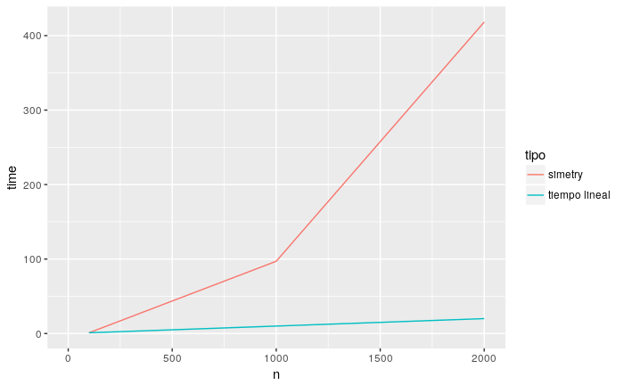

```r
tiempo <- data_frame(n = c(100,1000,2000,100,1000,2000), time = c(0.244/(0.244),23.672/0.244,102.053/0.244,1,10,20), tipo = c(rep("simetry",3),rep("tiempo lineal",3)))
ggplot(tiempo, aes(n,time, color = tipo))+
  geom_line()+
  scale_x_continuous(limits = c(0,2000))
```

```r
NA
```

Defino una función genérica

```r
similarity <- function(RCA){

  cualitative_RCA <- RCA %>%
  mutate(RCA = as.integer(case_when(RCA > 1 ~ 1,
                            RCA <= 1 ~ 0)))
  w <- cualitative_RCA %>% spread(., reporter,RCA,fill = 0) %>%
    ungroup()

  HS96 <- w$HS96
  mat <- as.matrix(w[,-1])
  v <- mat %*% t(mat)
  diag(v) <- 0
  dimnames(v) <- list(HS96, HS96)
  totales <- rowSums(w[,-1])
  probabilities <- v/totales

  # Hasta que no resuelva el problema de arriba, sólo calculo las probabilidades
  #symmetric_proba <- symmetric_max(probabilities)
  #return(symmetric_proba)
  return(probabilities)
  }
```

```r
probabilities <- similarity(RCA = expo)
write_csv(data.frame(probabilities),"resultados/probabilities.csv")
```

```r
test <- probabilities[0:10,0:10]
test
```

```
          010111    010119    010120    010210 010290 010310 010391    010392    010410 010420
010111 0.0000000 1.0000000 0.0000000 0.5000000    0.5    0.0      0 0.0000000 0.5000000    0.5
010119 1.0000000 0.0000000 0.0000000 0.5000000    0.5    0.0      0 0.0000000 0.5000000    0.5
010120 0.0000000 0.0000000 0.0000000 0.0000000    1.0    0.0      0 0.0000000 0.0000000    0.0
010210 1.0000000 1.0000000 0.0000000 0.0000000    1.0    0.0      0 0.0000000 1.0000000    0.0
010290 0.3333333 0.3333333 0.3333333 0.3333333    0.0    0.0      0 0.3333333 0.3333333    0.0
010310 0.0000000 0.0000000 0.0000000 0.0000000    0.0    0.0      0 0.0000000 1.0000000    0.0
010391 0.0000000 0.0000000 0.0000000 0.0000000    0.0    0.0      0 0.0000000 0.0000000    0.0
010392 0.0000000 0.0000000 0.0000000 0.0000000    1.0    0.0      0 0.0000000 0.0000000    0.0
010410 0.5000000 0.5000000 0.0000000 0.5000000    0.5    0.5      0 0.0000000 0.0000000    0.0
010420 1.0000000 1.0000000 0.0000000 0.0000000    0.0    0.0      0 0.0000000 0.0000000    0.0
```

Otro intento de calcular la similitud

```r
test <- probabilities[0:10,0:10]
test
```

```
          010111    010119    010120    010210 010290 010310 010391    010392    010410 010420
010111 0.0000000 1.0000000 0.0000000 0.5000000    0.5    0.0      0 0.0000000 0.5000000    0.5
010119 1.0000000 0.0000000 0.0000000 0.5000000    0.5    0.0      0 0.0000000 0.5000000    0.5
010120 0.0000000 0.0000000 0.0000000 0.0000000    1.0    0.0      0 0.0000000 0.0000000    0.0
010210 1.0000000 1.0000000 0.0000000 0.0000000    1.0    0.0      0 0.0000000 1.0000000    0.0
010290 0.3333333 0.3333333 0.3333333 0.3333333    0.0    0.0      0 0.3333333 0.3333333    0.0
010310 0.0000000 0.0000000 0.0000000 0.0000000    0.0    0.0      0 0.0000000 1.0000000    0.0
010391 0.0000000 0.0000000 0.0000000 0.0000000    0.0    0.0      0 0.0000000 0.0000000    0.0
010392 0.0000000 0.0000000 0.0000000 0.0000000    1.0    0.0      0 0.0000000 0.0000000    0.0
010410 0.5000000 0.5000000 0.0000000 0.5000000    0.5    0.5      0 0.0000000 0.0000000    0.0
010420 1.0000000 1.0000000 0.0000000 0.0000000    0.0    0.0      0 0.0000000 0.0000000    0.0
```

```r
test[test<t(test)] <- test[test<t(test)]
test[test>t(test)] <- t(test)[test>t(test)]
test
```

```
          010111    010119    010120    010210    010290 010310 010391    010392    010410 010420
010111 0.0000000 1.0000000 0.0000000 0.5000000 0.3333333    0.0      0 0.0000000 0.5000000    0.5
010119 1.0000000 0.0000000 0.0000000 0.5000000 0.3333333    0.0      0 0.0000000 0.5000000    0.5
010120 0.0000000 0.0000000 0.0000000 0.0000000 0.3333333    0.0      0 0.0000000 0.0000000    0.0
010210 0.5000000 0.5000000 0.0000000 0.0000000 0.3333333    0.0      0 0.0000000 0.5000000    0.0
010290 0.3333333 0.3333333 0.3333333 0.3333333 0.0000000    0.0      0 0.3333333 0.3333333    0.0
010310 0.0000000 0.0000000 0.0000000 0.0000000 0.0000000    0.0      0 0.0000000 0.5000000    0.0
010391 0.0000000 0.0000000 0.0000000 0.0000000 0.0000000    0.0      0 0.0000000 0.0000000    0.0
010392 0.0000000 0.0000000 0.0000000 0.0000000 0.3333333    0.0      0 0.0000000 0.0000000    0.0
010410 0.5000000 0.5000000 0.0000000 0.5000000 0.3333333    0.5      0 0.0000000 0.0000000    0.0
010420 0.5000000 0.5000000 0.0000000 0.0000000 0.0000000    0.0      0 0.0000000 0.0000000    0.0
```

```r
test==t(test)
```

```
       010111 010119 010120 010210 010290 010310 010391 010392 010410 010420
010111   TRUE   TRUE   TRUE   TRUE   TRUE   TRUE   TRUE   TRUE   TRUE   TRUE
010119   TRUE   TRUE   TRUE   TRUE   TRUE   TRUE   TRUE   TRUE   TRUE   TRUE
010120   TRUE   TRUE   TRUE   TRUE   TRUE   TRUE   TRUE   TRUE   TRUE   TRUE
010210   TRUE   TRUE   TRUE   TRUE   TRUE   TRUE   TRUE   TRUE   TRUE   TRUE
010290   TRUE   TRUE   TRUE   TRUE   TRUE   TRUE   TRUE   TRUE   TRUE   TRUE
010310   TRUE   TRUE   TRUE   TRUE   TRUE   TRUE   TRUE   TRUE   TRUE   TRUE
010391   TRUE   TRUE   TRUE   TRUE   TRUE   TRUE   TRUE   TRUE   TRUE   TRUE
010392   TRUE   TRUE   TRUE   TRUE   TRUE   TRUE   TRUE   TRUE   TRUE   TRUE
010410   TRUE   TRUE   TRUE   TRUE   TRUE   TRUE   TRUE   TRUE   TRUE   TRUE
010420   TRUE   TRUE   TRUE   TRUE   TRUE   TRUE   TRUE   TRUE   TRUE   TRUE
```

El resultado parece ser adecuado. Testeo performance

```r
symmetric_max <- function(M){
  M[M<t(M)] <- M[M<t(M)]
  M[M>t(M)] <- t(M)[M>t(M)]
  return(M)
}
```

```r
prueba0 <- probabilities[0:1,0:1]
prueba1 <- probabilities[0:10,0:10]
prueba2 <- probabilities[0:100,0:100]
prueba3 <- probabilities[0:1000,0:1000]
prueba4 <- probabilities[0:2000,0:2000]
prueba5 <- probabilities[0:3000,0:3000]
```

```r
system.time(probabilities_simetricas <- symmetric_max(prueba0))
```

```
   user  system elapsed
      0       0       0
```

```r
system.time(probabilities_simetricas <- symmetric_max(prueba1))
```

```
   user  system elapsed
  0.007   0.000   0.007
```

```r
system.time(probabilities_simetricas <- symmetric_max(prueba2))
```

```
   user  system elapsed
  0.001   0.000   0.001
```

```r
system.time(probabilities_simetricas <- symmetric_max(prueba3))
```

```
   user  system elapsed
  0.064   0.008   0.071
```

```r
system.time(probabilities_simetricas <- symmetric_max(prueba4))
```

```
   user  system elapsed
  0.280   0.024   0.305
```

```r
system.time(probabilities_simetricas <- symmetric_max(prueba5))
```

```
   user  system elapsed
  0.699   0.052   0.751
```

#### Performa bien!

Redefino la funcion de similitudes

```r
similarity <- function(RCA){

  cualitative_RCA <- RCA %>%
  mutate(RCA = as.integer(case_when(RCA > 1 ~ 1,
                            RCA <= 1 ~ 0)))
  w <- cualitative_RCA %>% spread(., reporter,RCA,fill = 0) %>%
    ungroup()

  HS96 <- w$HS96
  mat <- as.matrix(w[,-1])
  v <- mat %*% t(mat)
  diag(v) <- 0
  dimnames(v) <- list(HS96, HS96)
  totales <- rowSums(w[,-1])
  probabilities <- v/totales

  symmetric_proba <- symmetric_max(probabilities)
  return(symmetric_proba)
  }
```

```r
symmetric_proba <- similarity(RCA = expo)
write_csv(data.frame(symmetric_proba),"resultados/similitud.csv")
```